# R Notebook

# Summary Statistics

Below are the summary statistics for each condition in the data set (i.e., mean, standard deviation).

```r
data <- read.csv("assignment_dataVis_dataset.csv")

#mean
cond1_mean <- colMeans(data[1:142, 2:3])
cond2_mean <- colMeans(data[143:284, 2:3])
cond3_mean <- colMeans(data[285:426, 2:3])
cond4_mean <- colMeans(data[427:568, 2:3])

#sd
cond1_sd <- apply(data[1:142, 2:3], 2, sd)
cond2_sd <- apply(data[143:284, 2:3], 2, sd)
cond3_sd <- apply(data[285:426, 2:3], 2, sd)
cond4_sd <- apply(data[427:568, 2:3], 2, sd)

#table of summary statistics
summarystats <- data.frame(condition = c("cond1", "cond2", "cond3", "cond4"),
                                 mean_x = c(cond1_mean["x"], cond2_mean["x"], cond3_mean["x"], cond4_mean["x"]),
                                 mean_y = c(cond1_mean["y"], cond2_mean["y"], cond3_mean["y"], cond4_mean["y"]),
                                 sd_x = c(cond1_sd["x"], cond2_sd["x"], cond3_sd["x"], cond4_sd["x"]),
                                 sd_y = c(cond1_sd["y"], cond2_sd["y"], cond3_sd["y"], cond4_sd["y"])
                                 )
print(summarystats)
```

```
##   condition   mean_x   mean_y     sd_x     sd_y
## 1     cond1 54.26327 47.83225 16.76514 26.93540
## 2     cond2 54.26873 47.83082 16.76924 26.93573
## 3     cond3 54.26588 47.83150 16.76885 26.93861
## 4     cond4 54.26734 47.83955 16.76896 26.93027
```

# Data Visualization

Visualize the results of each condition. At very least, you should plot y as a function of x for each condition. You are welcome to create as many plots as you like. Try to apply the visualization best practices presented during lecture. Please create your plots in line in your notebook

### Scatter Plots without Error bars

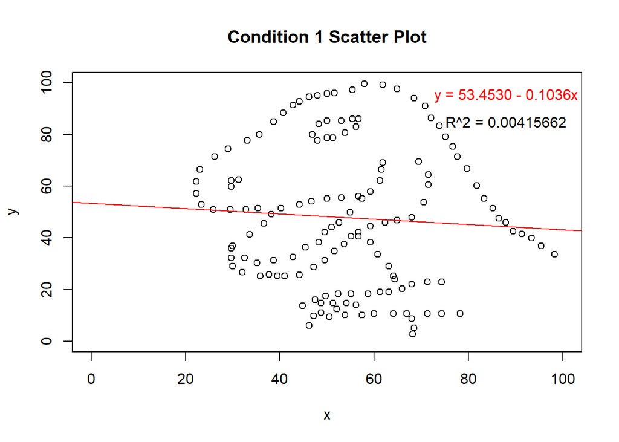

```r
# condition 1 scatter plot
reg1 <- lm(y~x, data = data[1:142, 2:3]) # y-intercept = 53.4530, slope = -0.1036
cor1 <- (cor(data[1:142, 2], data[1:142, 3])^2) # R^2 = 0.00415662 (very weak correlation)
cond1_plot <- plot(data[1:142, 2:3],
                     main = "Condition 1 Scatter Plot",
                     ylim = c(0,100),
                     xlim = c(0,100))
text(x=88, y=95, "y = 53.4530 - 0.1036x", col = "red")
text(x=88, y=85, "R^2 = 0.00415662", col = "black")
abline(coef= coef(reg1), col="red")
```

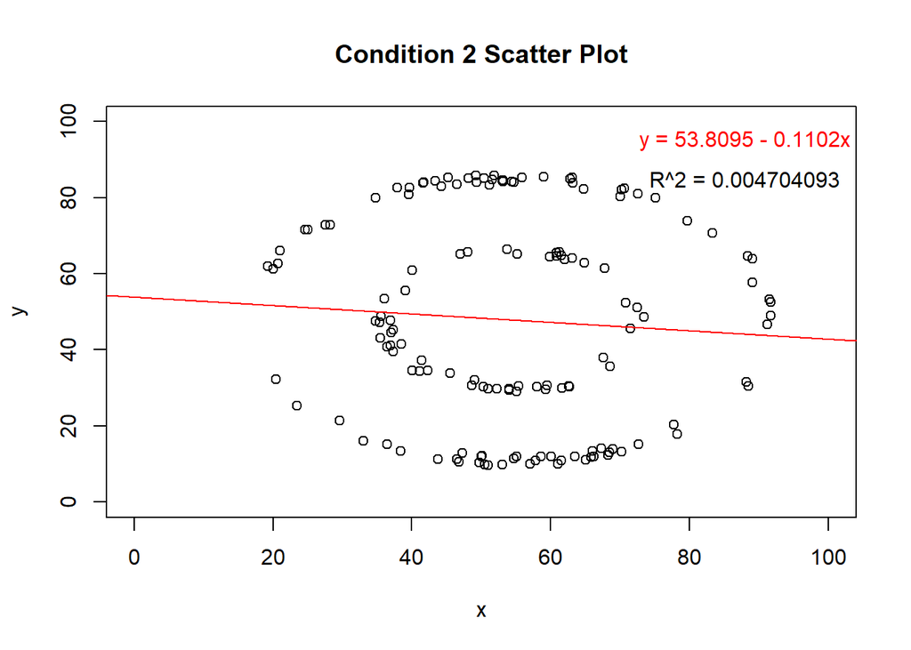

```r
# condition 2 scatter plot
reg2 <- lm(y~x, data = data[143:284, 2:3]) # y-intercept = 53.8095, slope = -0.1102
cor2 <- (cor(data[143:284, 2], data[143:284, 3])^2) # R^2 = 0.004704093 (very weak correlation)

cond2_plot <- plot(data[143:284, 2:3],
                     main = "Condition 2 Scatter Plot",
                     ylim = c(0,100),
                     xlim = c(0,100))
text(x=88, y=95, "y = 53.8095 - 0.1102x", col = "red")
text(x=88, y=85, "R^2 = 0.004704093", col = "black")
abline(coef= coef(reg2), col="red")
```

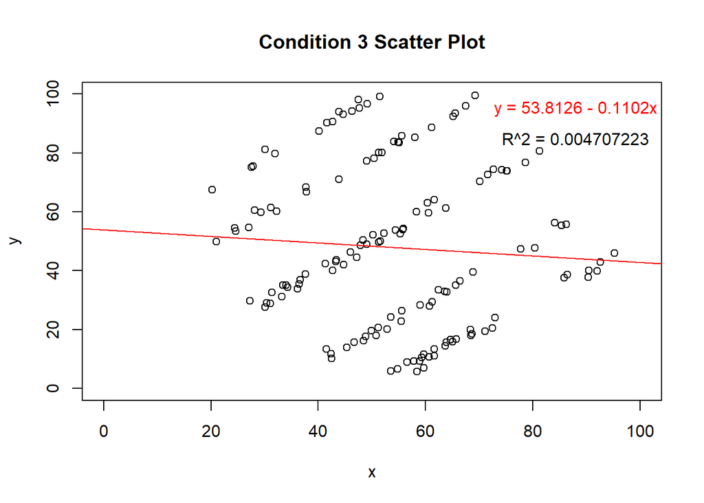

```r
# condition 3 scatter plot
reg3 <- lm(y~x, data = data[285:426, 2:3]) # y-intercept = 53.8126, slope = -0.1102
cor3 <- (cor(data[285:426, 2], data[285:426, 3])^2) # R^2 = 0.004707223 (very weak correlation)

cond3_plot <- plot(data[285:426, 2:3],
                     main = "Condition 3 Scatter Plot",
                     ylim = c(0,100),
                     xlim = c(0,100))
text(x=88, y=95, "y = 53.8126 - 0.1102x", col = "red")
text(x=88, y=85, "R^2 = 0.004707223", col = "black")
abline(coef= coef(reg3), col="red")
```

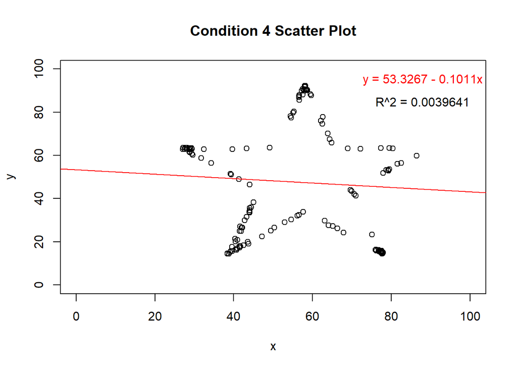

```r
# condition 4 scatter plot
reg4 <- lm(y~x, data = data[427:568, 2:3]) # y-intercept = 53.3267, slope = -0.1011
cor4 <- (cor(data[427:568, 2], data[427:568, 3])^2) # R^2 = 0.0039641 (very weak correlation)

cond4_plot <- plot(data[427:568, 2:3],
                     main = "Condition 4 Scatter Plot",
                     ylim = c(0,100),
                     xlim = c(0,100))
text(x=88, y=95, "y = 53.3267 - 0.1011x", col = "red")
text(x=88, y=85, "R^2 = 0.0039641", col = "black")

abline(coef= coef(reg4), col="red")
```

### Scatter Plots with Error bars

Error bars represent standard deviation.

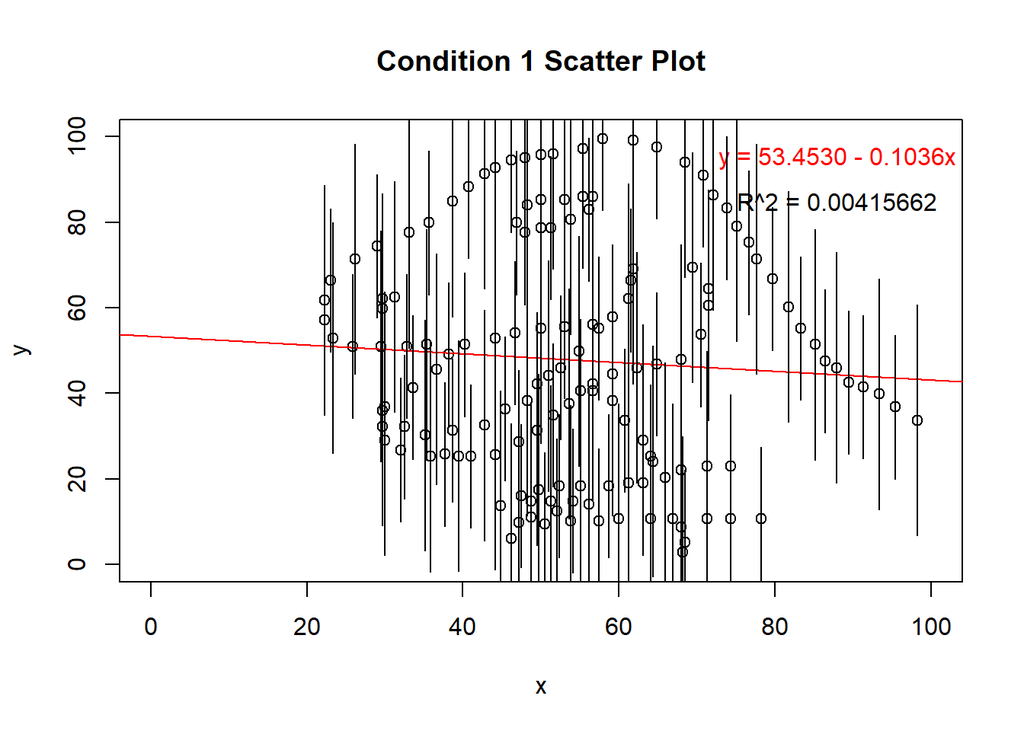

```r
# condition 1 scatter plot
reg1 <- lm(y~x, data = data[1:142, 2:3]) # y-intercept = 53.4530, slope = -0.1036
cor1 <- (cor(data[1:142, 2], data[1:142, 3])^2) # R^2 = 0.00415662 (very weak correlation)
cond1_plot <- plot(data[1:142, 2:3],
                     main = "Condition 1 Scatter Plot",
                     ylim = c(0,100),
                     xlim = c(0,100))
text(x=88, y=95, "y = 53.4530 - 0.1036x", col = "red")
text(x=88, y=85, "R^2 = 0.00415662", col = "black")
abline(coef= coef(reg1), col="red")
con1x <- data[1:142, 2]
con1y <- data[1:142, 3]
segments(con1x, (con1y+cond1_sd), con1x, (con1y-cond1_sd))
```

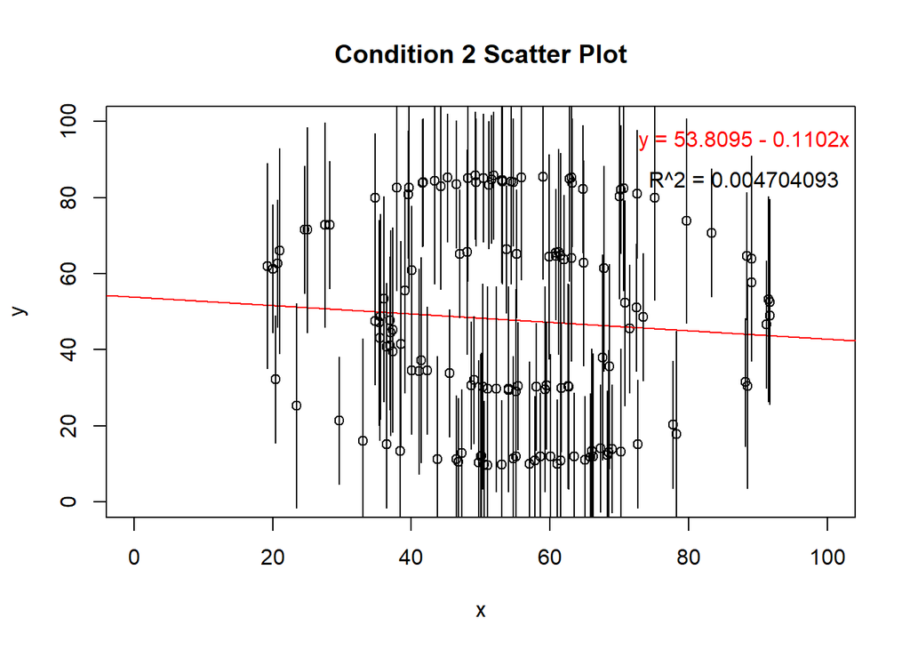

```r
# condition 2 scatter plot
reg2 <- lm(y~x, data = data[143:284, 2:3]) # y-intercept = 53.8095, slope = -0.1102
cor2 <- (cor(data[143:284, 2], data[143:284, 3])^2) # R^2 = 0.004704093 (very weak correlation)

cond2_plot <- plot(data[143:284, 2:3],
                     main = "Condition 2 Scatter Plot",
                     ylim = c(0,100),
                     xlim = c(0,100))
text(x=88, y=95, "y = 53.8095 - 0.1102x", col = "red")
text(x=88, y=85, "R^2 = 0.004704093", col = "black")
abline(coef= coef(reg2), col="red")
con2x <- data[143:284, 2]
con2y <- data[143:284, 3]
segments(con2x, (con2y+cond2_sd), con2x, (con2y-cond2_sd))
```

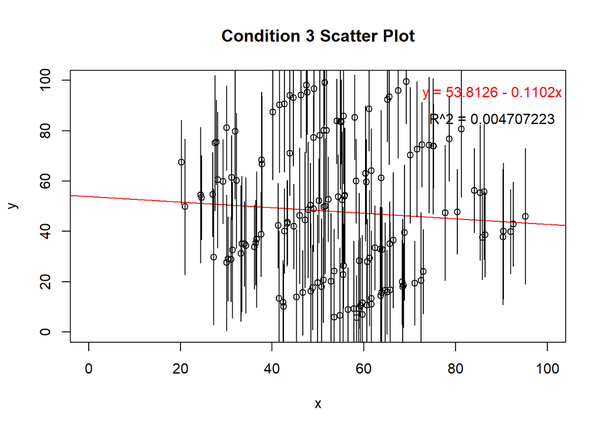

```r
# condition 3 scatter plot
reg3 <- lm(y~x, data = data[285:426, 2:3]) # y-intercept = 53.8126, slope = -0.1102
cor3 <- (cor(data[285:426, 2], data[285:426, 3])^2) # R^2 = 0.004707223 (very weak correlation)

cond3_plot <- plot(data[285:426, 2:3],
                     main = "Condition 3 Scatter Plot",
                     ylim = c(0,100),
                     xlim = c(0,100))
text(x=88, y=95, "y = 53.8126 - 0.1102x", col = "red")
text(x=88, y=85, "R^2 = 0.004707223", col = "black")
abline(coef= coef(reg3), col="red")
con3x <- data[285:426, 2]
con3y <- data[285:426, 3]
segments(con3x, (con3y+cond3_sd), con3x, (con3y-cond3_sd))
```

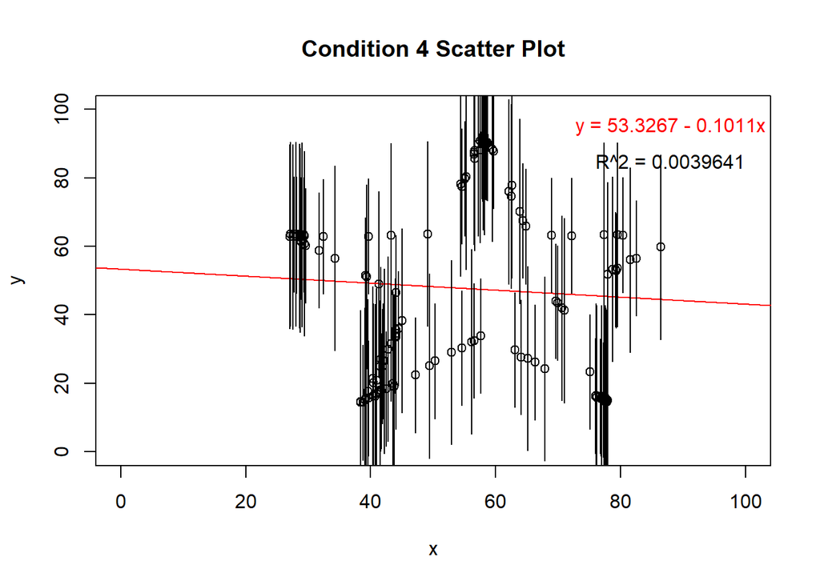

```r
# condition 4 scatter plot
reg4 <- lm(y~x, data = data[427:568, 2:3]) # y-intercept = 53.3267, slope = -0.1011
cor4 <- (cor(data[427:568, 2], data[427:568, 3])^2) # R^2 = 0.0039641 (very weak correlation)

cond4_plot <- plot(data[427:568, 2:3],
                     main = "Condition 4 Scatter Plot",
                     ylim = c(0,100),
                     xlim = c(0,100))
text(x=88, y=95, "y = 53.3267 - 0.1011x", col = "red")
text(x=88, y=85, "R^2 = 0.0039641", col = "black")
abline(coef= coef(reg4), col="red")
con4x <- data[427:568, 2]
con4y <- data[427:568, 3]
segments(con4x, (con4y+cond4_sd), con4x, (con4y-cond4_sd))
```

### Box Plots

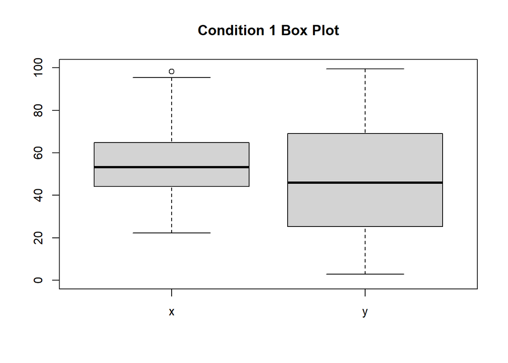

```r
# condition 1 box plot
con1_bp <- boxplot(data[1:142, 2:3],
                   main = "Condition 1 Box Plot",
                   ylim = c(0,100))
```

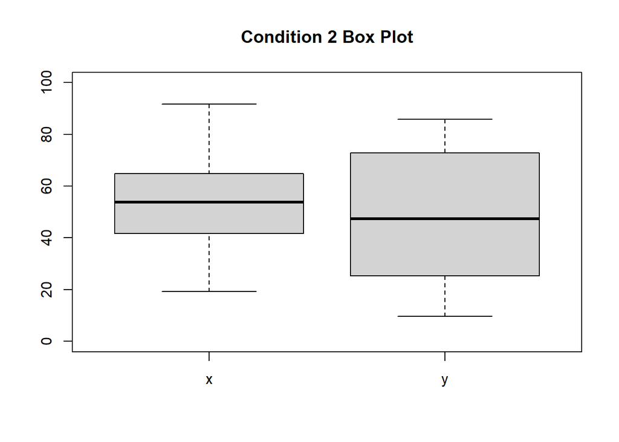

```r
# condition 2 box plot
con2_bp <- boxplot(data[143:284, 2:3],
                   main = "Condition 2 Box Plot",
                   ylim = c(0,100))
```

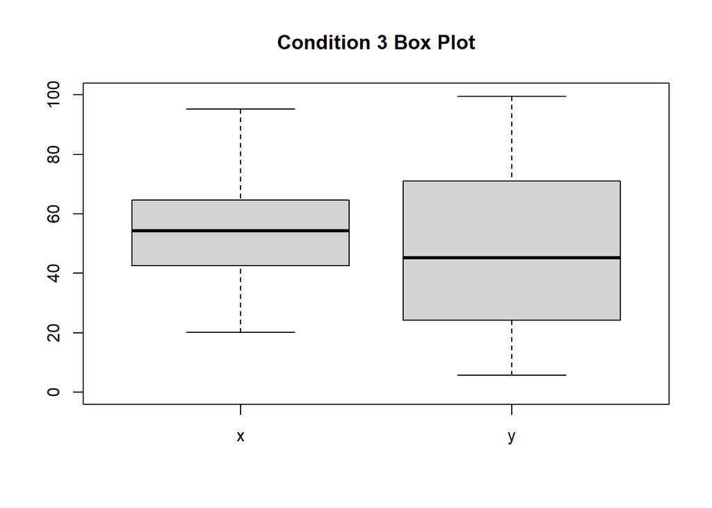

```r
# condition 3 box plot
con3_bp <- boxplot(data[285:426, 2:3],
                   main = "Condition 3 Box Plot",
                   ylim = c(0,100))
```

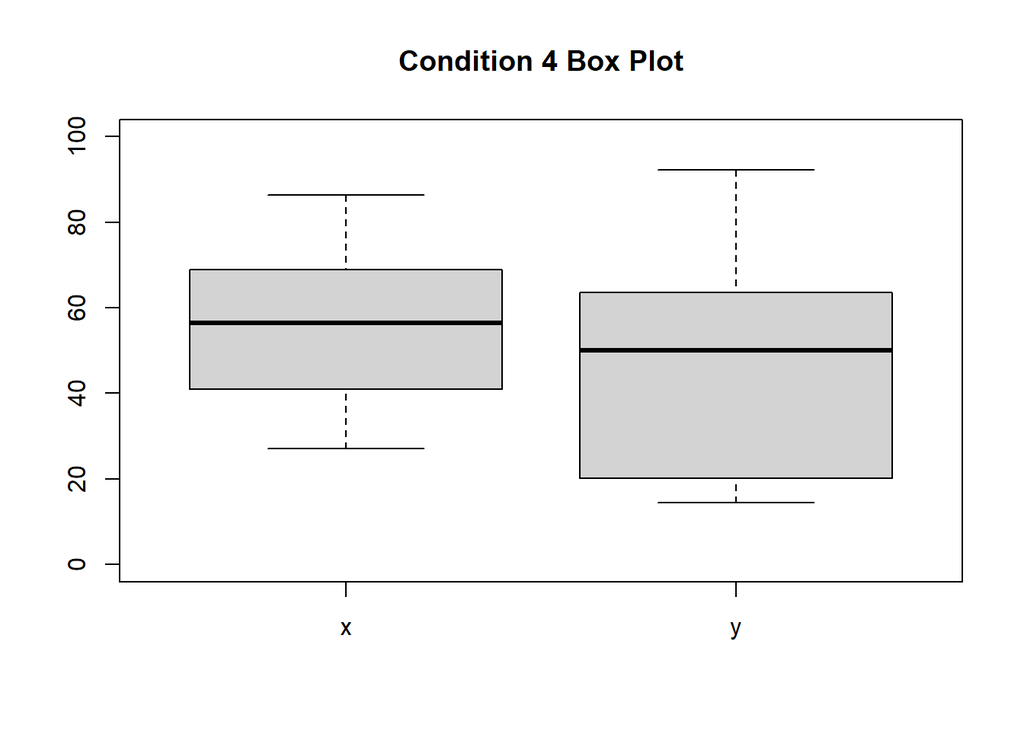

```r
# condition 4 box plot
con4_bp <- boxplot(data[427:568, 2:3],
                   main = "Condition 4 Box Plot",
                   ylim = c(0,100))
```

# Questions

#### What can be concluded from the dataset?

The data show that there is no (or very weak) correlation between x and y in all 4 conditions.

#### What did you find most challenging about this assignment?

Trying to figure out how to implement the visualization best practices for each plot. I included scatter plots of each condition with and without error bars but found that the plots with error bars were crowded and more difficult to read and thus interpret. So I thought that a box plot would show the varaiation in the data better. I included all three plots in the script.

#### What did you learn in completing this assignment? What are you still curious about?

I learned the importance of visualizing data because the summary statistics for each condition had the same/similar values (for mean and standard deviation), but through plotting the data, I could see that they present very different figures even though they share the same means and standard deviations.

#### Why is it important to visualize data?

It gives us a better understanding of what is going on in the data and allows for more efficient analyses and interpretations. Raw data presented in a table can be analyzed by comparing values to each other, but it is time consuming and not ideal. When data is visualized through a graph/plot, it provides a logical structure for comparing data points, identifying trends, and interpretation of findings through looking at the whole data set. It can allow us to draw conclusions on what statistical tests and methods are appropriate for the construct being measured.